# Simulation and Estimation for each group

Kazi Tanvir Hasan and Dr. Gabriel Odom

# Introduction

This vignette demonstrates how to simulate **multivariate normal data** and **multivariate skewed Gamma data** using **pre-estimated statistics** or datasets.

In this guide, we cover the following steps:

1. **Simulate Multivariate Normal Data**: Use pre-estimated statistics (mean vector and covariance matrix) to generate multivariate normal data using the `simulate_group_data()` function with `MASS::mvrnorm()` data generation function.
2. **Estimate Multivariate Moments**: Using a dataset to estimate key statistics such as mean, variance, correlation, and skewness using `calculate_stats_gaussian()` function.
3. **Simulate Multivariate Skewed Gamma Data**: Use pre-estimated statistics to generate multivariate skewed Gamma data using the `simulate_group_data()` function with `generate_mvGamma_data` data generation function.
4. **Estimate Multivariate Skewed Gamma Parameters**: Estimate skewed Gamma distribution parameters (shape and rate) using the `calculate_stats_gamma()` function. Choose either **Method of Moments (MoM)** or **Generalized Maximum Likelihood Estimation (gMLE)** methods based on an existing dataset.

## Setup

We will load the necessary libraries and assume that we already have pre-estimated statistics for the multivariate normal and skewed Gamma data generation.

```r
# Load necessary libraries
library(MASS)         # For generating multivariate normal data
library(simBKMRdata)  # For generating skewed Gamma data and estimating moments
```

## Simulate Multivariate Normal Data (Using Pre-Estimated Statistics)

Given the pre-estimated mean vector and covariance matrix, we can generate multivariate normal data using the `MASS::mvrnorm()` function.

```r
# Example using MASS::mvrnorm for normal distribution
param_list <- list(
  Group1 = list(
    mean_vec = c(1, 2),
    sampCorr_mat = matrix(c(1, 0.5, 0.5, 1), 2, 2),
    sampSize = 100
  ),
  Group2 = list(
    mean_vec = c(2, 3),
    sampCorr_mat = matrix(c(1, 0.3, 0.3, 1), 2, 2),
    sampSize = 150
  )
)

mvnorm_samples <- simulate_group_data(param_list, MASS::mvrnorm, "Group")
```

### Visualizing the Multivariate Normal Data

Let’s visualize the first two variables of the generated multivariate normal data.

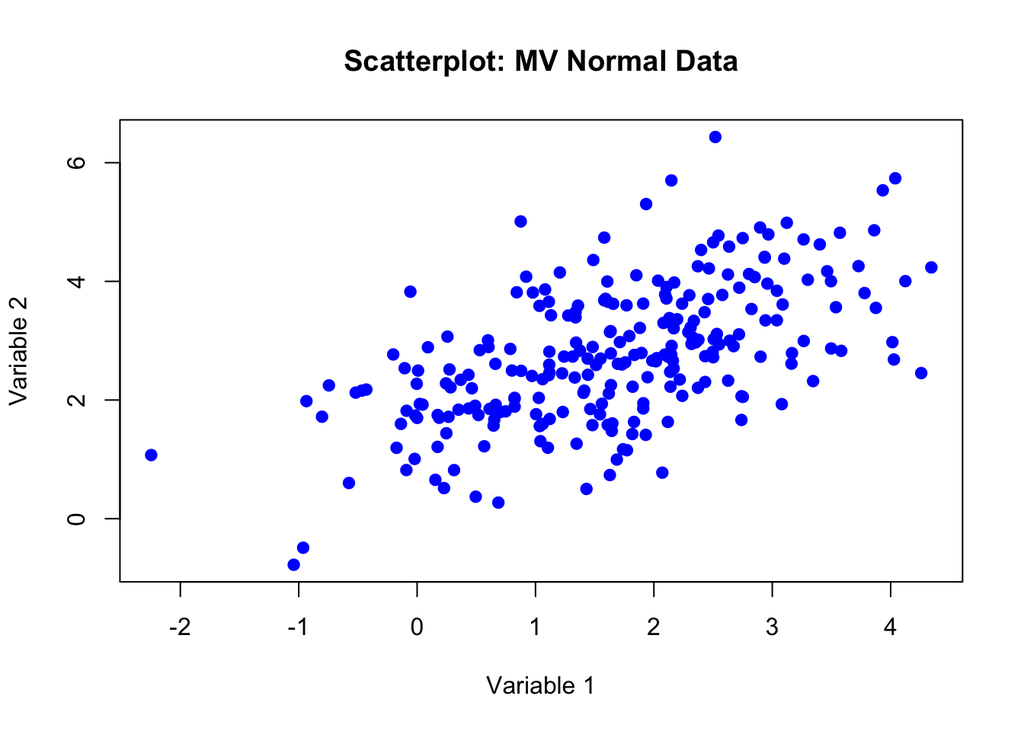

```r
# Plot the first two variables of the multivariate normal data
plot(
  mvnorm_samples[, 1], mvnorm_samples[, 2],
  main = "Scatterplot: MV Normal Data",
  xlab = "Variable 1", ylab = "Variable 2",
  pch = 19, col = "blue"
)
```

## 2. Estimate Multivariate Moments (Using an Existing Dataset)

### Example: Estimating Moments from an Existing Dataset

```r
myData <- data.frame(
  GENDER = c('Male', 'Female', 'Male', 'Female', 'Male', 'Female'),
  VALUE1 = c(1.2, 2.3, 1.5, 2.7, 1.35, 2.5),
  VALUE2 = c(3.4, 4.5, 3.8, 4.2, 3.6, 4.35)
)
calculate_stats_gaussian(data_df = myData, group_col = "GENDER")
```

```
$Female
$Female$sampSize
[1] 3

$Female$mean_vec
VALUE1 VALUE2
  2.50   4.35

$Female$sampSD
VALUE1 VALUE2
  0.20   0.15

$Female$sampCorr_mat
       VALUE1 VALUE2
VALUE1      1     -1
VALUE2     -1      1

$Female$sampSkew
[1] 0.00000e+00 5.91091e-15


$Male
$Male$sampSize
[1] 3

$Male$mean_vec
VALUE1 VALUE2
  1.35   3.60

$Male$sampSD
VALUE1 VALUE2
  0.15   0.20

$Male$sampCorr_mat
       VALUE1 VALUE2
VALUE1      1      1
VALUE2      1      1

$Male$sampSkew
[1] -4.411766e-15  2.240684e-15
```

### Output Explanation

The moment_estimates object contains:

- sampSize: The number of observations.
- mean_vec: Mean vector for each variable.
- sampSD: Standard deviation of each variable.
- sampCorr_mat: The correlation matrix.
- sampSkew: The skewness for each variable.

## 3. Simulate Multivariate Skewed Gamma Data (Using Pre-Estimated Statistics)

We can now generate multivariate skewed Gamma data based on pre-estimated shape and rate parameters for the Gamma distribution. This can be done using the `generate_mvGamma_data` function.

```r
# Example using generate_mvGamma_data for Gamma distribution
param_list <- list(
   Group1 = list(
     sampCorr_mat = matrix(c(1, 0.5, 0.5, 1), 2, 2),
     shape_num = c(2, 2),
     rate_num = c(1, 1),
     sampSize = 100
   ),
   Group2 = list(
     sampCorr_mat = matrix(c(1, 0.3, 0.3, 1), 2, 2),
     shape_num = c(2, 2),
     rate_num = c(1, 1),
     sampSize = 150
   )

)

gamma_samples <- simulate_group_data(
  param_list, generate_mvGamma_data, "Group"
)
```

### Visualizing the Skewed Gamma Data

Let’s plot the density of the first two variables of the generated skewed Gamma data.

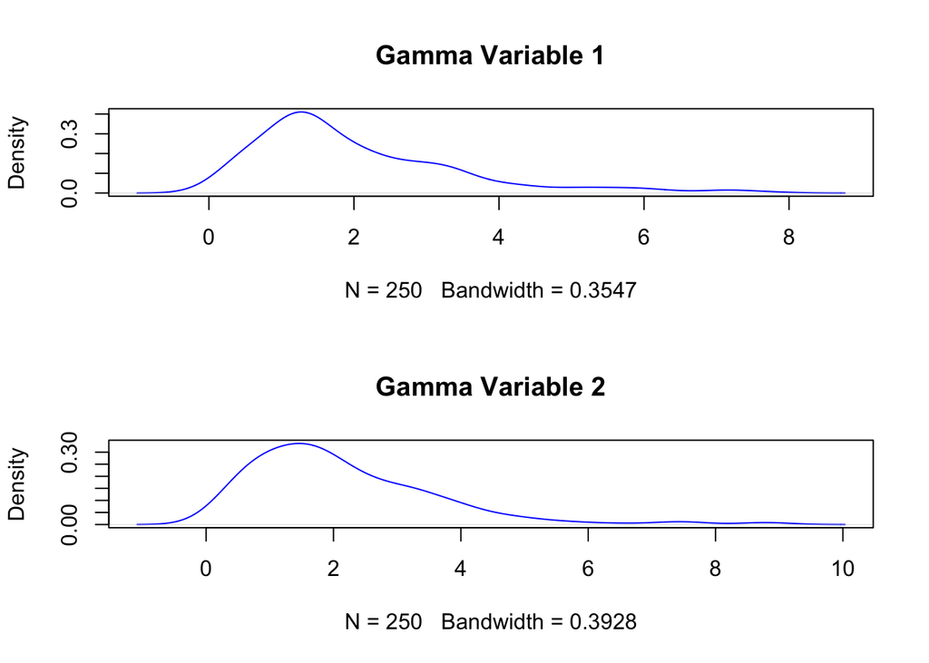

```r
# Plot the density of the first and second variable for Gamma data
old_par_mfrow <- par()[["mfrow"]]
par(mfrow = c(2, 1))
plot(density(gamma_samples[, 1]), main = "Gamma Variable 1", col = "blue")
plot(density(gamma_samples[, 2]), main = "Gamma Variable 2", col = "blue")
```

```r
par(mfrow = old_par_mfrow)
```

## 4. Estimate Multivariate Skewed Gamma Parameters (Using an Existing Dataset)

If we have an existing dataset, we can estimate the parameters of the multivariate skewed Gamma distribution using methods such as Method of Moments (MoM) or Generalized Maximum Likelihood Estimation (gMLE).

### Example: Estimating Skewed Gamma Parameters Using MoM

```r
myData <- data.frame(
   GENDER = c('Male', 'Female', 'Male', 'Female', 'Male', 'Female'),
   VALUE1 = c(1.2, 2.3, 1.5, 2.7, 1.35, 2.5),
   VALUE2 = c(3.4, 4.5, 3.8, 4.2, 3.6, 4.35)
)
calculate_stats_gamma(data_df = myData, group_col= "GENDER", using = "MoM")
```

```
$Female
$Female$sampSize
[1] 3

$Female$mean_vec
VALUE1 VALUE2
  2.50   4.35

$Female$sampCorr_mat
       VALUE1 VALUE2
VALUE1      1     -1
VALUE2     -1      1

$Female$shape_num
VALUE1 VALUE2
156.25 841.00

$Female$rate_num
  VALUE1   VALUE2
 62.5000 193.3333


$Male
$Male$sampSize
[1] 3

$Male$mean_vec
VALUE1 VALUE2
  1.35   3.60

$Male$sampCorr_mat
       VALUE1 VALUE2
VALUE1      1      1
VALUE2      1      1

$Male$shape_num
VALUE1 VALUE2
    81    324

$Male$rate_num
VALUE1 VALUE2
    60     90
```

### Output Explanation

# Conclusion

In this vignette, we demonstrated how to:

- Simulate multivariate normal data using pre-estimated mean and covariance parameters.
- Estimate multivariate moments (mean, variance, correlation, skewness) from an existing dataset.
- Simulate multivariate skewed Gamma data using pre-estimated shape and rate parameters.
- Estimate skewed Gamma parameters using existing data with Method of Moments (MoM).

These methods allow you to generate and analyze synthetic multivariate datasets with specific properties based on pre-estimated statistics or available data, which is useful for simulations and statistical analysis in various domains such as finance, healthcare, and engineering.